# ROP meta-analysis

Aman Josan

30/03/22

### Type 1 ROP - Gestational age, birth weight and postmenstrual age as potential moderators

All studies which considered type 1 ROP

| study | treatment-Bevacizumab | treatment-Ranibizumab | treatment-Aflibercept | treatment-Laser | study design | no. Eyes-Bevacizumab | no. Eyes-Ranibizumab | no. Eyes-Aflibercept | no. Eyes-Laser | mean gestational age - Avastin (wks) | mean gestational age - Lucentis (wks) | mean gestational age - Eylea (wks) | mean gestational age - Laser (wks) | mean birth weight - Avastin (wks) | mean birth weight - Lucentis (wks) | mean birth weight - Eylea (wks) | mean birth weight - Laser (wks) | mean PMA at tx (weeks)- Avastin | mean PMA at tx (weeks)- Lucentis | mean PMA at tx (weeks)- Eylea | mean PMA at tx (weeks)- Laser | no. responders-Bevacizumab | no. responders-Ranibizumab | no. responders-Aflibercept | no. responders-Laser |
| --- | --- | --- | --- | --- | --- | --- | --- | --- | --- | --- | --- | --- | --- | --- | --- | --- | --- | --- | --- | --- | --- | --- | --- | --- | --- |
| Demir 2019 | IVB(0.625 mg/0.025ml) | NA | NA | laser photocoagulation | r | 57 | 0 | 0 | 64 | NA | NA | NA | NA | NA | NA | NA | NA | 35.20 | NA | NA | 36.30 | 48 | NA | NA | 47 |
| Murakami 2021 | IVB (0.625 mg/0.025 ml) | NA | NA | laser | r | 24 | 0 | 0 | 28 | 26.80 | NA | NA | 25.70 | 816.00 | NA | NA | 722.000 | NA | NA | NA | NA | 20 | NA | NA | 28 |
| Hwang 2015 | IVB (0.625mg/0.025ml) | NA | NA | laser PRP (32) | r | 22 | 0 | 0 | 32 | 24.20 | NA | NA | 24.80 | 668.10 | NA | NA | 701.400 | 35.10 | NA | NA | 36.10 | 19 | NA | NA | 31 |
| Kong 2015 | IVB (0.625mg/0.025mL) | NA | NA | laser | r | 43 | 0 | 0 | 37 | 24.30 | NA | NA | 24.80 | 645.00 | NA | NA | 669.000 | 35.70 | NA | NA | 37.40 | 40 | NA | NA | 33 |
| Isaac 2015 | IVB (0.625mg/0.025ml) | NA | NA | laser | r | 23 | 0 | 0 | 22 | 25.20 | NA | NA | 25.00 | 722.00 | NA | NA | 674.000 | 37.60 | NA | NA | 36.70 | 23 | NA | NA | 21 |
| Mintz Hittner 2011 | IVB(0.625mg/0.025mL) | NA | NA | laser | RCT | 140 | 0 | 0 | 146 | 24.20 | NA | NA | 24.30 | 656.64 | NA | NA | 670.364 | 34.50 | NA | NA | 33.70 | 134 | NA | NA | 114 |
| Chen 2018a | IVB(0.625 mg) | NA | NA | diode laser photocoag | r | 29 | 0 | 0 | 20 | 24.98 | NA | NA | 24.62 | 662.33 | NA | NA | 688.300 | 34.71 | NA | NA | 36.05 | 1 | NA | NA | 18 |
| Mueller 2017 | IVB 0.625 mg (0.025 ml) | NA | NA | laser | r | 74 | 0 | 0 | 34 | NA | NA | NA | NA | NA | NA | NA | NA | 33.70 | NA | NA | 40.10 | 64 | NA | NA | 34 |
| Nicoara 2016 | IVB 0.625 mg (0.025 ml) | NA | NA | laser | r | 34 | 0 | 0 | 12 | 28.29 | NA | NA | 29.83 | 1094.71 | NA | NA | 1198.330 | 34.41 | NA | NA | 36.33 | 31 | NA | NA | 10 |
| Zhang 2017 | NA | IVR (0.3mg/0.03mL) | NA | laser | RCT | 0 | 50 | 0 | 50 | NA | 28.96 | NA | 28.27 | NA | 1220.0000 | NA | 1060.000 | NA | NA | NA | NA | NA | 24 | NA | 48 |
| Chmielarz-Czarnocinska 2021 | NA | IVR (0.25 mg/0.025 m) | NA | laser | r | 0 | 120 | 0 | 226 | NA | NA | NA | NA | NA | NA | NA | NA | NA | NA | NA | NA | NA | 40 | NA | 180 |
| Leng 2018 | NA | IVR (0.25mg) | NA | laser | r | 0 | 24 | 0 | 98 | NA | 28.76 | NA | 31.37 | NA | 1074.0000 | NA | 1566.000 | NA | NA | NA | NA | NA | 14 | NA | 56 |
| Chan 2016 | NA | IVR (0.25 mg/0.025 ml) | NA | laser | r | 0 | 8 | 0 | 10 | NA | 24.00 | NA | 26.71 | NA | 592.5000 | NA | 786.200 | NA | 36.00 | NA | 40.00 | NA | 2 | NA | 8 |
| Ekinci 2020 | NA | NA | IVA 1mg/0.025mL(24) | laser(27) | r | 0 | 0 | 24 | 27 | NA | NA | 27.30 | 28.70 | NA | NA | 1095.0 | 1281.000 | NA | NA | 34.2 | 37.60 | NA | NA | 18 | 25 |
| Riazi-esfahani 2021 | IVB(0.625mg/0.025mL) | NA | IVA 1mg/0.025mL | NA | r | 865 | 0 | 24 | 0 | 28.20 | NA | 28.70 | NA | NA | NA | 1205.0 | NA | NA | NA | NA | NA | 831 | NA | 10 | NA |
| Sukgen 2019 | NA | IVR 0.25 mg/0.025 mL (54) | IVA 1 mg/0.025 mL,(72) | NA | r | 0 | 54 | 72 | 0 | NA | 28.35 | 28.30 | NA | NA | 1126.7000 | 1157.6 | NA | NA | 35.30 | 34.7 | NA | NA | 42 | 66 | NA |
| Suren 2022 | IVB(0.625mg/0.025mL) | IVR(0.25mg/0.025mL) | IVA 1 mg/0.025 mL | NA | r | 54 | 77 | 56 | 0 | 27.00 | 28.00 | 27.00 | NA | 1060.00 | 1066.0000 | 984.0 | NA | 36.00 | 36.00 | 36.0 | NA | 46 | 58 | 48 | NA |
| Kabatas 2017 | IVB(0.625mg/0.025mL) | IVR(0.25mg/0.025mL) | NA | laser | r | 24 | 12 | 0 | 72 | 26.10 | 26.00 | NA | 27.70 | 841.00 | 840.0000 | NA | 1112.000 | 35.00 | 34.30 | NA | 36.50 | 22 | 10 | NA | 62 |
| Ling 2020 | IVB(0.625mg/0.025mL) | IVR(0.25mg/0.025mL) | NA | laser | r | 231 | 48 | 0 | 61 | 26.40 | 26.20 | NA | 26.50 | 851.60 | 827.9000 | NA | 902.400 | 36.20 | 36.00 | NA | 36.30 | 208 | 38 | NA | 50 |
| Gunay 2016 | IVB (0.625mg/0.025mL) | IVR (0.25/0.025mL) | NA | laser | r | 107 | 44 | 0 | 113 | 27.31 | 27.95 | NA | 28.23 | 1005.29 | 1195.9000 | NA | 1119.470 | 34.75 | 35.59 | NA | 36.03 | 101 | 38 | NA | 113 |
| Wong 2015 | IVB (0.625 mg/0.025 mL) | IVR ( 0.25 mg/0.025 mL) | NA | NA | r | 4 | 6 | 0 | 0 | 22.72 | 23.93 | NA | NA | 612.50 | 641.6667 | NA | NA | 33.43 | 35.72 | NA | NA | 4 | 3 | NA | NA |
| Kang 2018 | IVB (0.625 mg/0.025 mL) | IVR (0.2 mg/0.02 mL) | NA | NA | r | 101 | 52 | 0 | 0 | 26.90 | 28.10 | NA | NA | 941.80 | 1257.7000 | NA | NA | 40.40 | 39.20 | NA | NA | 93 | 45 | NA | NA |
| Chen 2018b | IVB (0.625 mg/0.025 mL) | IVR (0.25 mg/0.025 mL) | NA | NA | r | 40 | 26 | 0 | 0 | 27.06 | 26.54 | NA | NA | 911.08 | 856.1500 | NA | NA | 37.19 | 36.12 | NA | NA | 36 | 26 | NA | NA |
| Erol 2015 | IVB (0.625mg) | IVR (0.25mg) | NA | NA | r | 21 | 15 | 0 | 0 | 27.10 | 26.20 | NA | NA | 925.00 | 853.0000 | NA | NA | 35.30 | 34.40 | NA | NA | 19 | 11 | NA | NA |
| Kimyon 2018 | IVB (0.625mg/0.025mL) | IVR (0.25mg/0.025mL) | NA | NA | r | 40 | 28 | 0 | 0 | 29.30 | 30.10 | NA | NA | 1360.50 | 1389.0000 | NA | NA | 35.70 | 35.50 | NA | NA | 36 | 26 | NA | NA |
| Lyu 2019 | NA | IVR (0.25mg/0.025mL) | NA | laser | r | 0 | 17 | 0 | 10 | NA | 29.00 | NA | 28.80 | NA | 1200.5000 | NA | 1275.000 | NA | 40.80 | NA | 42.60 | NA | 15 | NA | 7 |
| Mori 2020 | IVB (0.625mg/0.025mL) | NA | NA | laser | r | 26 | 0 | 0 | 106 | NA | NA | NA | NA | NA | NA | NA | NA | NA | NA | NA | NA | 14 | NA | NA | 98 |
| Zayek 2021 | IVB (0.625mg/0.025mL) | NA | NA | laser | r | 122 | 0 | 0 | 170 | 23.00 | NA | NA | 24.00 | 481.00 | NA | NA | 545.000 | 34.00 | NA | NA | 35.00 | 102 | NA | NA | 166 |
| Fleck 2022 | NA | IVR (0.2 mg) | NA | laser | post-hoc analysis of RCT | 0 | 146 | 0 | 138 | NA | 25.00 | NA | 26.00 | NA | 791.0000 | NA | 831.000 | NA | 36.70 | NA | 36.60 | NA | 106 | NA | 104 |
| FIREFLEYE 2022 | NA | NA | IVA 0.4 mg (0.01 mL) | laser | RCT | 0 | 0 | 150 | 76 | NA | NA | 26.43 | 26.00 | NA | NA | NA | NA | NA | NA | NA | NA | NA | NA | 139 | 69 |

number of studies=30

Number of patients=4686

## Event count data and conventional meta-analysis of proportions

### Transform data (Dichotomous data)

Here we define the number of responders as the number of patients treated minus the number of patients requiring retreatment. Hence the measure of treatment effectiveness we are applying is the number of patients requiring no retreatment.

Since we are dealing with raw prevalence (or event rate) data (i.e. sample size and number of treatment responders) rather than correlations (i.e. Pearsons r for treatment correlations) we need to perform a meta-analysis of proportions. Most meta-analysis in the literature deal with correlations and p-values.

The proportion of treatment responders ($p$) is given by

$$\begin{align}
p = \frac{x}{n}
\end{align}$$

where $x$ is the number of treatment responders in a study and $n$ is the total number treated with that treatment in the study.

Again data is quite skewed (as is normally the case in number of event data), hence use double arcsine transformation for the conventional meta-analysis again.

Avastin

| capture.output.metafor_Avastin_res_mod. |
| --- |
| Mixed-Effects Model (k = 16; tau^2 estimator: REML) |
| tau^2 (estimated amount of residual heterogeneity): 0.0712 (SE = 0.0321) |
| tau (square root of estimated tau^2 value): 0.2668 |
| I^2 (residual heterogeneity / unaccounted variability): 94.03% |
| H^2 (unaccounted variability / sampling variability): 16.74 |
| R^2 (amount of heterogeneity accounted for): 0.00% |
| Test for Residual Heterogeneity: |
| QE(df = 12) = 133.5908, p-val < .0001 |
| Test of Moderators (coefficients 2:4): |
| QM(df = 3) = 1.8953, p-val = 0.5944 |
| Model Results: |
| estimate se zval pval ci.lb ci.ub |
| intrcpt 2.7190 2.9437 0.9237 0.3556 -3.0505 8.4886 |
| g.age -0.1627 0.1546 -1.0519 0.2929 -0.4658 0.1404 |
| b.weight 0.0014 0.0012 1.1379 0.2552 -0.0010 0.0038 |
| pma 0.0426 0.0469 0.9085 0.3636 -0.0494 0.1346 |
| — |
| Signif. codes: 0 ‘**’ 0.001 ’**’ 0.01 ’’ 0.05 ‘.’ 0.1 ’ ’ 1 |

Lucentis

| capture.output.metafor_Lucentis_res_mod. |
| --- |
| Mixed-Effects Model (k = 13; tau^2 estimator: REML) |
| tau^2 (estimated amount of residual heterogeneity): 0.0206 (SE = 0.0141) |
| tau (square root of estimated tau^2 value): 0.1434 |
| I^2 (residual heterogeneity / unaccounted variability): 73.39% |
| H^2 (unaccounted variability / sampling variability): 3.76 |
| R^2 (amount of heterogeneity accounted for): 0.00% |
| Test for Residual Heterogeneity: |
| QE(df = 9) = 28.4509, p-val = 0.0008 |
| Test of Moderators (coefficients 2:4): |
| QM(df = 3) = 5.1960, p-val = 0.1580 |
| Model Results: |
| estimate se zval pval ci.lb ci.ub |
| intrcpt -1.4305 2.5443 -0.5622 0.5739 -6.4173 3.5563 |
| g.age 0.0970 0.1050 0.9236 0.3557 -0.1088 0.3027 |
| b.weight -0.0003 0.0008 -0.3282 0.7427 -0.0018 0.0013 |
| pma 0.0048 0.0312 0.1527 0.8786 -0.0564 0.0659 |
| — |
| Signif. codes: 0 ‘**’ 0.001 ’**’ 0.01 ’’ 0.05 ‘.’ 0.1 ’ ’ 1 |

Laser

| capture.output.metafor_Laser_res_mod. |
| --- |
| Mixed-Effects Model (k = 14; tau^2 estimator: REML) |
| tau^2 (estimated amount of residual heterogeneity): 0.0233 (SE = 0.0133) |
| tau (square root of estimated tau^2 value): 0.1526 |
| I^2 (residual heterogeneity / unaccounted variability): 83.26% |
| H^2 (unaccounted variability / sampling variability): 5.97 |
| R^2 (amount of heterogeneity accounted for): 0.00% |
| Test for Residual Heterogeneity: |
| QE(df = 10) = 81.3668, p-val < .0001 |
| Test of Moderators (coefficients 2:4): |
| QM(df = 3) = 1.3147, p-val = 0.7256 |
| Model Results: |
| estimate se zval pval ci.lb ci.ub |
| intrcpt 1.8243 2.1909 0.8327 0.4050 -2.4699 6.1184 |
| g.age 0.0263 0.1074 0.2447 0.8067 -0.1841 0.2367 |
| b.weight -0.0002 0.0008 -0.1905 0.8489 -0.0017 0.0014 |
| pma -0.0317 0.0293 -1.0835 0.2786 -0.0891 0.0257 |
| — |
| Signif. codes: 0 ‘**’ 0.001 ’**’ 0.01 ’’ 0.05 ‘.’ 0.1 ’ ’ 1 |

Eylea

| capture.output.metafor_Eylea_res_mod. |
| --- |
| Mixed-Effects Model (k = 4; tau^2 estimator: REML) |
| tau^2 (estimated amount of residual heterogeneity): 0.1237 (SE = 0.1833) |
| tau (square root of estimated tau^2 value): 0.3517 |
| I^2 (residual heterogeneity / unaccounted variability): 95.47% |
| H^2 (unaccounted variability / sampling variability): 22.06 |
| R^2 (amount of heterogeneity accounted for): 0.00% |
| Test for Residual Heterogeneity: |
| QE(df = 1) = 22.0592, p-val < .0001 |
| Test of Moderators (coefficients 2:3): |
| QM(df = 2) = 0.3848, p-val = 0.8250 |
| Model Results: |
| estimate se zval pval ci.lb ci.ub |
| intrcpt 1.8382 15.0046 0.1225 0.9025 -27.5703 31.2466 |
| g.age 0.0371 0.7778 0.0477 0.9619 -1.4873 1.5615 |
| b.weight -0.0016 0.0065 -0.2513 0.8016 -0.0144 0.0112 |
| — |
| Signif. codes: 0 ‘**’ 0.001 ’**’ 0.01 ’’ 0.05 ‘.’ 0.1 ’ ’ 1 |

Eylea

| capture.output.metafor_Eylea_res_mod2. |
| --- |
| Mixed-Effects Model (k = 3; tau^2 estimator: REML) |
| tau^2 (estimated amount of residual heterogeneity): 0.0177 (SE = 0.0331) |
| tau (square root of estimated tau^2 value): 0.1331 |
| I^2 (residual heterogeneity / unaccounted variability): 75.67% |
| H^2 (unaccounted variability / sampling variability): 4.11 |
| R^2 (amount of heterogeneity accounted for): 0.00% |
| Test for Residual Heterogeneity: |
| QE(df = 1) = 4.1098, p-val = 0.0426 |
| Test of Moderators (coefficient 2): |
| QM(df = 1) = 0.0972, p-val = 0.7552 |
| Model Results: |
| estimate se zval pval ci.lb ci.ub |
| intrcpt -0.1143 4.1201 -0.0277 0.9779 -8.1896 7.9610 |
| pma 0.0367 0.1176 0.3118 0.7552 -0.1939 0.2672 |
| — |
| Signif. codes: 0 ‘**’ 0.001 ’**’ 0.01 ’’ 0.05 ‘.’ 0.1 ’ ’ 1 |

Looking at the lines titled “test of moderators” and “g.age”, “b.weight” and “pma” under “model results” we see that the model predictions find neither gestational age, birth weight nor mean postmenstrual age at treatment have a significant moderating factor.

For example for those treated with laser, the p-value for the combined moderating effect of GA, BW & pma has a p-value=0.7256 and with individual moderating effect p-values for GA=0.8067 and BW=0.8489 and pma=0.2786.

Hence all treatments now have non-significant correlations for gestational age and birth weight and PMA at treatment as moderators for effect size. Eylea moderator analysis had to be split into two parts.The first analyses the effects of all combinations of g.age and birth weight individually and together on the effect size. The second analyses the moderating effect of PMA alone on the effect size. It was not possible to combine PMA with g.age and birth weight to analyse combinations of all moderators as there are too few PMA samples for Eylea. No moderating effects were found for Eylea.

Performing a frequentist meta-regression and generating a scatter plot with regression line and confidence intervals to see the relationship although now there is no significant correlation so these plots can be mostly ignored. Here I’ve only shown plots for gestational age as birth weight plots look pretty similar. I can plot them if needed but as they are non-significant I haven’t bothered here.

Hence, for Lucentis, flat-ish line shows there is no real correlation to GA (especially when taking confidence interval widths into account, i.e. line could be completely flat):

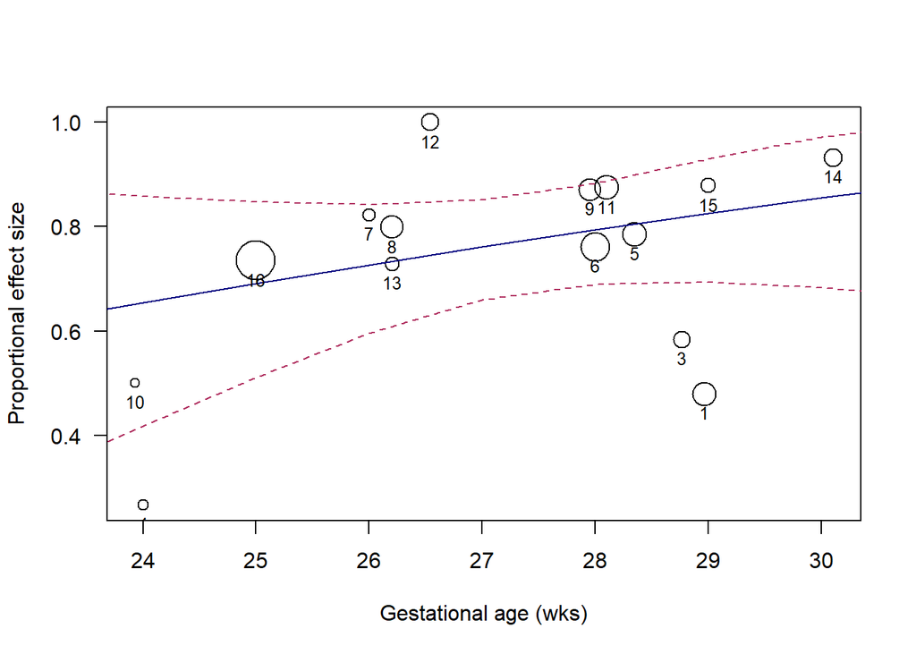

Ranibizumab studies and assigned ID’s

| Study | Authors | Sample size | Gestational age (weeks) | Birth weight (g) | PMA at treatment (weeks |
| --- | --- | --- | --- | --- | --- |
| 1 | Zhang 2017 | 24 | 28.96 | 1220.0000 | NA |
| 2 | Chmielarz-Czarnocinska 2021 | 40 | NA | NA | NA |
| 3 | Leng 2018 | 14 | 28.76 | 1074.0000 | NA |
| 4 | Chan 2016 | 2 | 24.00 | 592.5000 | 36.00 |
| 5 | Sukgen 2019 | 42 | 28.35 | 1126.7000 | 35.30 |
| 6 | Suren 2022 | 58 | 28.00 | 1066.0000 | 36.00 |
| 7 | Kabatas 2017 | 10 | 26.00 | 840.0000 | 34.30 |
| 8 | Ling 2020 | 38 | 26.20 | 827.9000 | 36.00 |
| 9 | Gunay 2016 | 38 | 27.95 | 1195.9000 | 35.59 |
| 10 | Wong 2015 | 3 | 23.93 | 641.6667 | 35.72 |
| 11 | Kang 2018 | 45 | 28.10 | 1257.7000 | 39.20 |
| 12 | Chen 2018b | 26 | 26.54 | 856.1500 | 36.12 |
| 13 | Erol 2015 | 11 | 26.20 | 853.0000 | 34.40 |
| 14 | Kimyon 2018 | 26 | 30.10 | 1389.0000 | 35.50 |
| 15 | Lyu 2019 | 15 | 29.00 | 1200.5000 | 40.80 |
| 16 | Fleck 2022 | 106 | 25.00 | 791.0000 | 36.70 |

N.B. Larger circles represent larger studies.

Scatterplot for Avastin again showing a flat-ish line representing no real correlation (completely flat line cannot be excluded when looking at the CI)

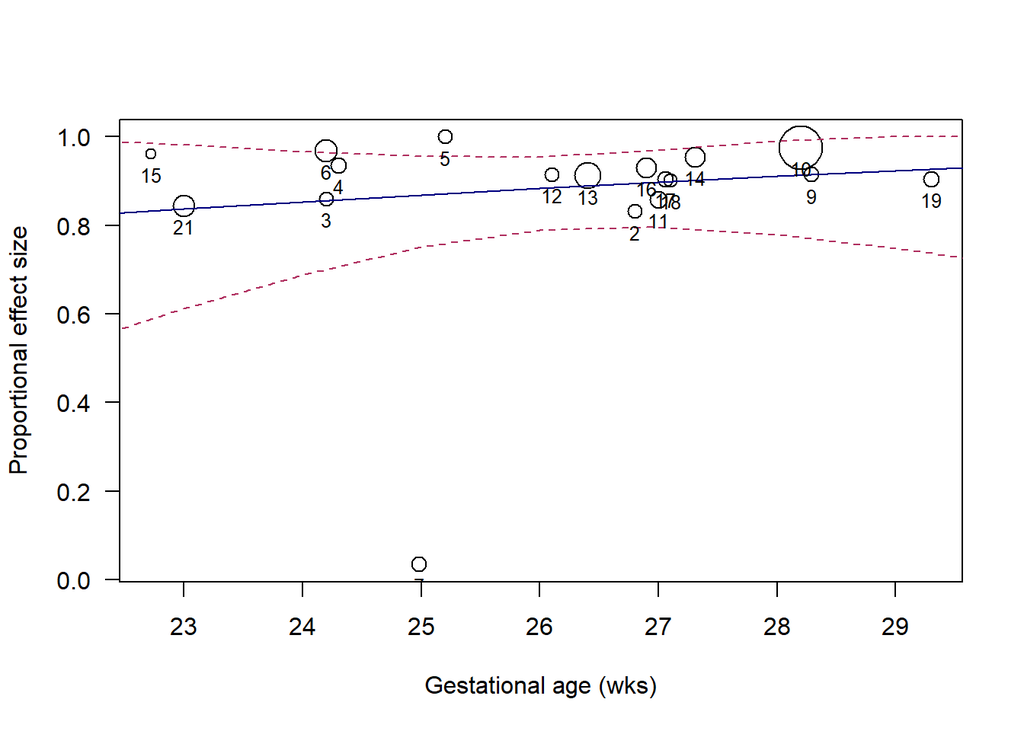

Bevacizumab

| Study | Authors | Sample size | Gestational age (weeks) | Birth weight (g) | PMA at treatment (weeks) |
| --- | --- | --- | --- | --- | --- |
| 1 | Demir 2019 | 48 | NA | NA | 35.20 |
| 2 | Murakami 2021 | 20 | 26.80 | 816.00 | NA |
| 3 | Hwang 2015 | 19 | 24.20 | 668.10 | 35.10 |
| 4 | Kong 2015 | 40 | 24.30 | 645.00 | 35.70 |
| 5 | Isaac 2015 | 23 | 25.20 | 722.00 | 37.60 |
| 6 | Mintz Hittner 2011 | 134 | 24.20 | 656.64 | 34.50 |
| 7 | Chen 2018a | 1 | 24.98 | 662.33 | 34.71 |
| 8 | Mueller 2017 | 64 | NA | NA | 33.70 |
| 9 | Nicoara 2016 | 31 | 28.29 | 1094.71 | 34.41 |
| 10 | Riazi-esfahani 2021 | 831 | 28.20 | NA | NA |
| 11 | Suren 2022 | 46 | 27.00 | 1060.00 | 36.00 |
| 12 | Kabatas 2017 | 22 | 26.10 | 841.00 | 35.00 |
| 13 | Ling 2020 | 208 | 26.40 | 851.60 | 36.20 |
| 14 | Gunay 2016 | 101 | 27.31 | 1005.29 | 34.75 |
| 15 | Wong 2015 | 4 | 22.72 | 612.50 | 33.43 |
| 16 | Kang 2018 | 93 | 26.90 | 941.80 | 40.40 |
| 17 | Chen 2018b | 36 | 27.06 | 911.08 | 37.19 |
| 18 | Erol 2015 | 19 | 27.10 | 925.00 | 35.30 |
| 19 | Kimyon 2018 | 36 | 29.30 | 1360.50 | 35.70 |
| 20 | Mori 2020 | 14 | NA | NA | NA |
| 21 | Zayek 2021 | 102 | 23.00 | 481.00 | 34.00 |

Scatterplot for Laser again showing no real correlation (completely flat line cannot be excluded when looking at the CI)

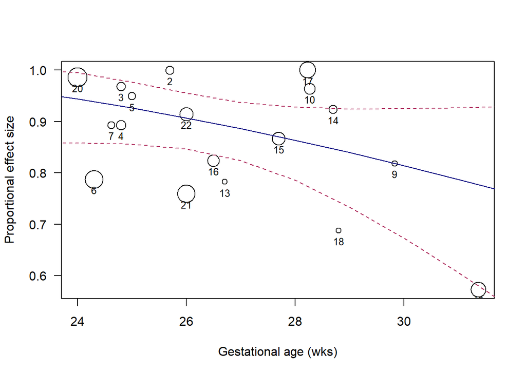

Laser

| Study | Authors | Sample size | Gestational age (weeks) | Birth weight (g) | PMA at treatment (weeks) |
| --- | --- | --- | --- | --- | --- |
| 1 | Demir 2019 | 47 | NA | NA | 36.30 |
| 2 | Murakami 2021 | 28 | 25.70 | 722.000 | NA |
| 3 | Hwang 2015 | 31 | 24.80 | 701.400 | 36.10 |
| 4 | Kong 2015 | 33 | 24.80 | 669.000 | 37.40 |
| 5 | Isaac 2015 | 21 | 25.00 | 674.000 | 36.70 |
| 6 | Mintz Hittner 2011 | 114 | 24.30 | 670.364 | 33.70 |
| 7 | Chen 2018a | 18 | 24.62 | 688.300 | 36.05 |
| 8 | Mueller 2017 | 34 | NA | NA | 40.10 |
| 9 | Nicoara 2016 | 10 | 29.83 | 1198.330 | 36.33 |
| 10 | Zhang 2017 | 48 | 28.27 | 1060.000 | NA |
| 11 | Chmielarz-Czarnocinska 2021 | 180 | NA | NA | NA |
| 12 | Leng 2018 | 56 | 31.37 | 1566.000 | NA |
| 13 | Chan 2016 | 8 | 26.71 | 786.200 | 40.00 |
| 14 | Ekinci 2020 | 25 | 28.70 | 1281.000 | 37.60 |
| 15 | Kabatas 2017 | 62 | 27.70 | 1112.000 | 36.50 |
| 16 | Ling 2020 | 50 | 26.50 | 902.400 | 36.30 |
| 17 | Gunay 2016 | 113 | 28.23 | 1119.470 | 36.03 |
| 18 | Lyu 2019 | 7 | 28.80 | 1275.000 | 42.60 |
| 19 | Mori 2020 | 98 | NA | NA | NA |
| 20 | Zayek 2021 | 166 | 24.00 | 545.000 | 35.00 |
| 21 | Fleck 2022 | 104 | 26.00 | 831.000 | 36.60 |
| 22 | FIREFLEYE 2022 | 69 | 26.00 | NA | NA |

Scatterplot for Eylea again showing no real correlation (completely flat line cannot be excluded when looking at the CI)

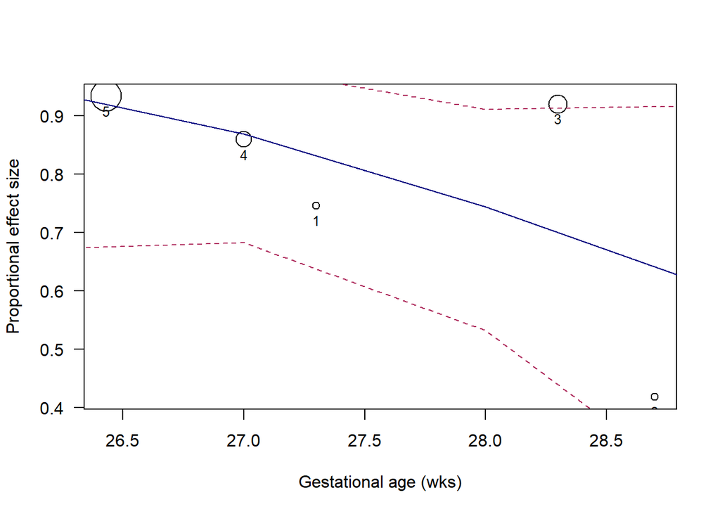

Aflibercept

| Study | Authors | Sample size | Gestational age (weeks) | Birth weight (g) | PMA at treatment (weeks) |
| --- | --- | --- | --- | --- | --- |
| 1 | Ekinci 2020 | 18 | 27.30 | 1095.0 | 34.2 |
| 2 | Riazi-esfahani 2021 | 10 | 28.70 | 1205.0 | NA |
| 3 | Sukgen 2019 | 66 | 28.30 | 1157.6 | 34.7 |
| 4 | Suren 2022 | 48 | 27.00 | 984.0 | 36.0 |
| 5 | FIREFLEYE 2022 | 139 | 26.43 | NA | NA |

Recall this is a conventional frequentist meta-analysis/meta-regression and so does not compare relative effect sizes of treatments. It is simply to show whether gestational age, birth weight and/or postmenstrual age provides a significant contributing factor towards the positive response effect size for each treatment individually. Bayesian analsysis is needed to compare one treatement vs another - coming next.

Compare GA group means between Avastin and Lucentis (with normality and equal variance test) using student t-test

```
    Shapiro-Wilk normality test

data:  df$`mean gestational age - Lucentis (wks)`
W = 0.93877, p-value = 0.3671
```

```
    F test to compare two variances

data:  df$`mean gestational age - Avastin (wks)` and df$`mean gestational age - Lucentis (wks)`
F = 0.95962, num df = 17, denom df = 14, p-value = 0.9234
alternative hypothesis: true ratio of variances is not equal to 1
95 percent confidence interval:
 0.3308737 2.6414867
sample estimates:
ratio of variances
         0.9596191
```

```
    Two Sample t-test

data:  df$`mean gestational age - Avastin (wks)` and df$`mean gestational age - Lucentis (wks)`
t = -1.6519, df = 31, p-value = 0.1086
alternative hypothesis: true difference in means is not equal to 0
95 percent confidence interval:
 -2.4143805  0.2534917
sample estimates:
mean of x mean of y
 26.05889  27.13933
```

## Bayesian network meta-analysis

## Meta-Regression

### Gestational age as a regressor in the Bayesian meta-regression (potential moderator)

```
$Description
[1] "MTC dataset: Bayesian NMA"

$`Studies per treatment`
Aflibercept Bevacizumab       Laser Ranibizumab
          5          18          18          15

$`Number of n-arm studies`
2-arm 3-arm
   22     4

$`Studies per treatment comparison`
           t1          t2 nr
1 Aflibercept Bevacizumab  2
2 Aflibercept       Laser  2
3 Aflibercept Ranibizumab  2
4 Bevacizumab       Laser 11
5 Bevacizumab Ranibizumab  9
6       Laser Ranibizumab  8
```

Network plot (line thickness connecting nodes denotes the number studies for each comparison)

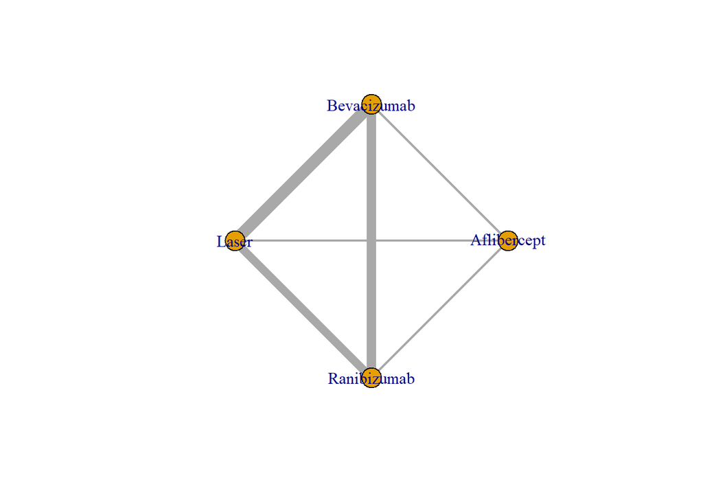

```
Results on the Log Risk Ratio scale

Iterations = 8010:208000
Thinning interval = 10
Number of chains = 4
Sample size per chain = 20000

1. Empirical mean and standard deviation for each variable,
   plus standard error of the mean:

                              Mean     SD Naive SE Time-series SE
d.Aflibercept.Bevacizumab -0.03411 1.0372 0.003667       0.014972
d.Aflibercept.Laser       -0.43264 1.0057 0.003556       0.014003
d.Aflibercept.Ranibizumab  0.56530 1.0513 0.003717       0.015112
sd.d                       1.44168 0.3151 0.001114       0.002087
beta[1]                    1.56255 2.7717 0.009800       0.054142
beta[2]                    0.04353 0.9145 0.003233       0.009954
beta[4]                   -0.48757 0.9513 0.003363       0.013547

2. Quantiles for each variable:

                             2.5%     25%      50%    75% 97.5%
d.Aflibercept.Bevacizumab -2.0506 -0.7135 -0.04729 0.6351 2.047
d.Aflibercept.Laser       -2.4192 -1.0852 -0.43147 0.2198 1.553
d.Aflibercept.Ranibizumab -1.4887 -0.1210  0.55494 1.2431 2.674
sd.d                       0.9421  1.2183  1.40121 1.6200 2.173
beta[1]                   -3.5980 -0.2256  1.40186 3.2522 7.398
beta[2]                   -1.6947 -0.5657  0.02512 0.6319 1.905
beta[4]                   -2.4343 -1.0971 -0.46148 0.1483 1.312

-- Model fit (residual deviance):

     Dbar        pD       DIC
 59.38459  48.03517 107.41976

56 data points, ratio 1.06, I^2 = 7%

-- Regression settings:

Regression on "gest.age", unrelated coefficients, "Laser" as control
Input standardized: x' = (gest.age - 26.41769) / 3.83026
Estimates at the centering value: gest.age = 26.41769
```

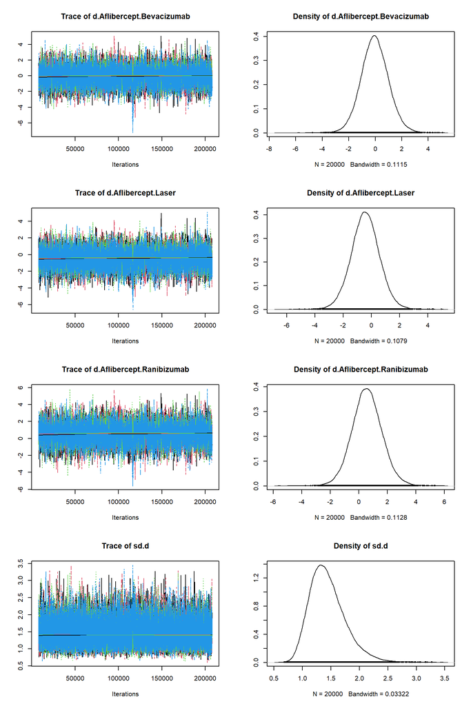

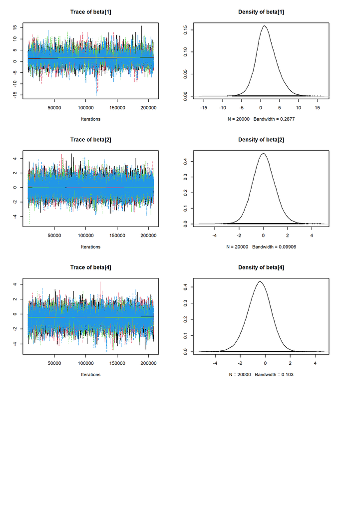

Here are comparative forest plots comparing treatment effects against one another. I have fixed the gestational age to 26 weeks for illustrative purposes but the range of gestational ages is shown in the covariate plots below these forest plots.

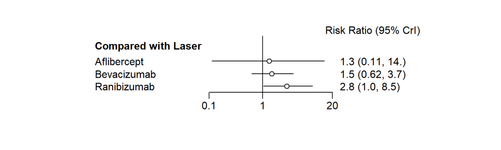

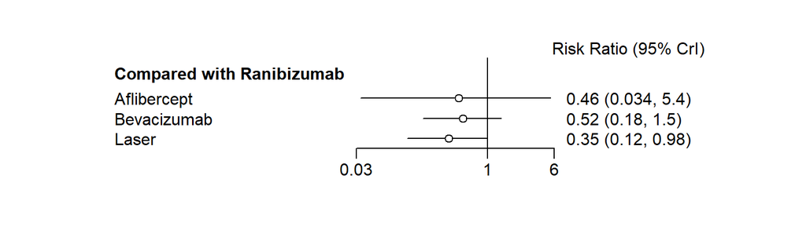

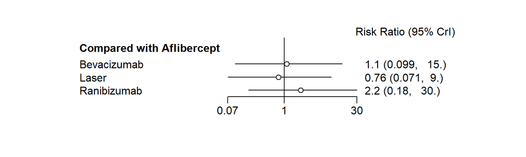

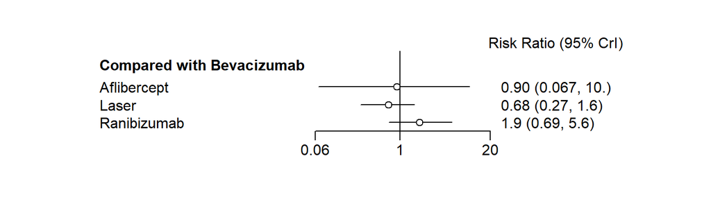

## Covariate plots for gestational age

Covariate plots below are in log(RR) units.

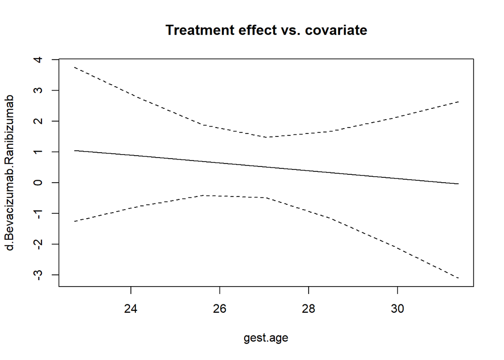

From the above covariate plot we can see there are no statistically significant differences between Avastin and Lucentis outcomes across gestational ages (credible intervals always incorporate zero).

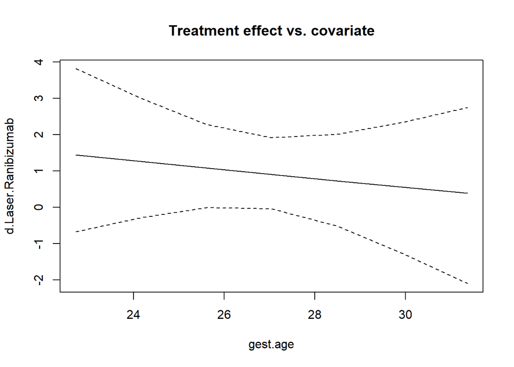

UPDATE (30/03/22) - we seem to have an even smaller band of statistical significance. Between 25.8 and 26.7 weeks GA, Laser is associated with a statistically significant reduction in risk of requiring retreatment when compared to Lucentis.

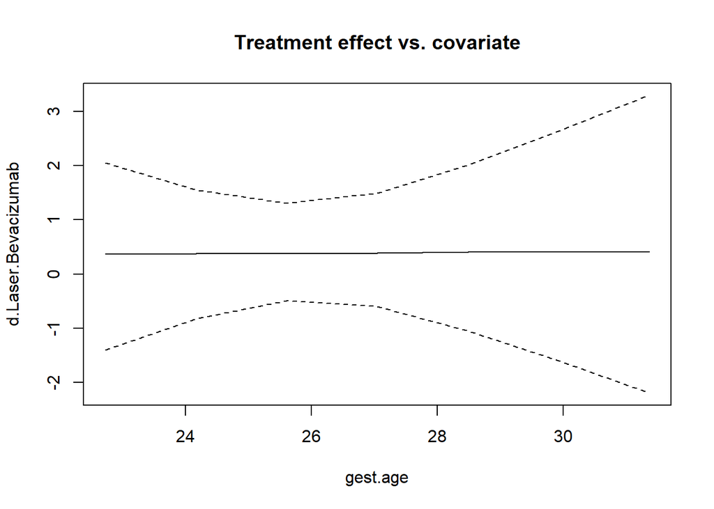

UPDATE (30/03/22) - Again we now have no statististical differences here at any gestational age

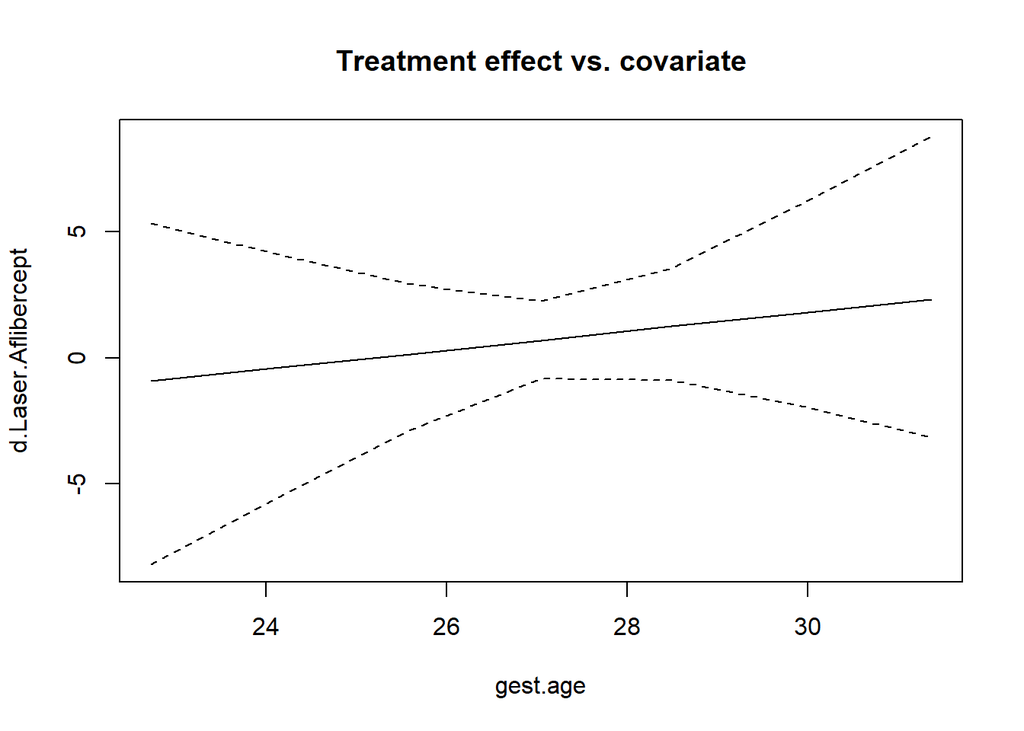

All Eylea combination plots look the same as above whereby the are no statistically significant differences between Eylea and all other treatments for any GA. (N.B only Eylea vs Laser shown here but all other Eylea comparisons look very similar).

Summary

UPDATE (30/03/22) - Between 25.8 and 26.7 weeks GA, Laser is associated with a statistically significant reduction in risk of requiring retreatment when compared to Lucentis. No moderating effect of g.age found on any other treatment modality comparison.

### Birth weight as a regressor in the Bayesian meta-regression (potential moderator)

```
Results on the Log Risk Ratio scale

Iterations = 8010:208000
Thinning interval = 10
Number of chains = 4
Sample size per chain = 20000

1. Empirical mean and standard deviation for each variable,
   plus standard error of the mean:

                              Mean     SD Naive SE Time-series SE
d.Aflibercept.Bevacizumab -0.20928 2.6612 0.009409       0.104717
d.Aflibercept.Laser       -0.72539 2.6881 0.009504       0.107208
d.Aflibercept.Ranibizumab  0.23882 2.6812 0.009479       0.105991
sd.d                       1.36964 0.3272 0.001157       0.002100
beta[1]                   -0.64477 5.8349 0.020630       0.241281
beta[2]                    0.07736 0.9216 0.003258       0.008736
beta[4]                   -0.31647 0.9551 0.003377       0.012911

2. Quantiles for each variable:

                              2.5%    25%      50%    75%  97.5%
d.Aflibercept.Bevacizumab  -6.3440 -1.472 -0.08461 1.2068  4.938
d.Aflibercept.Laser        -6.9158 -2.006 -0.59869 0.7072  4.454
d.Aflibercept.Ranibizumab  -5.9369 -1.040  0.35768 1.6681  5.426
sd.d                        0.8545  1.138  1.32790 1.5534  2.136
beta[1]                   -14.5051 -3.091 -0.33045 2.1674 10.674
beta[2]                    -1.6991 -0.530  0.06193 0.6638  1.947
beta[4]                    -2.2047 -0.937 -0.30838 0.3106  1.564

-- Model fit (residual deviance):

    Dbar       pD      DIC
55.91918 43.95940 99.87858

52 data points, ratio 1.075, I^2 = 9%

-- Regression settings:

Regression on "b.weight", unrelated coefficients, "Laser" as control
Input standardized: x' = (b.weight - 889.7604) / 464.9007
Estimates at the centering value: b.weight = 889.7604
```

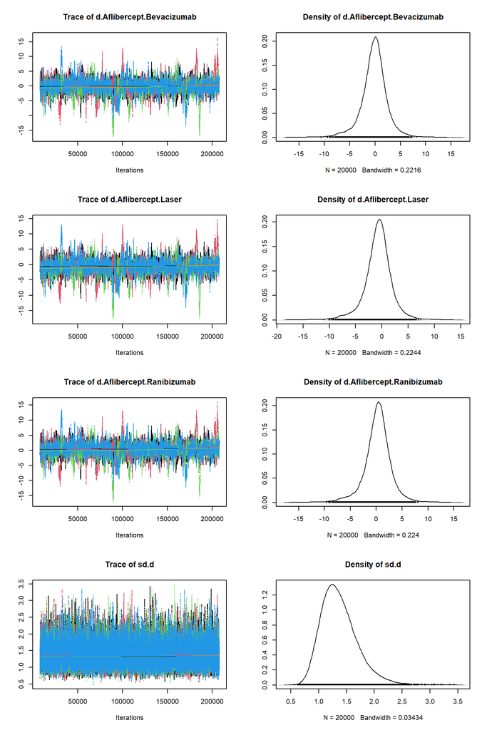

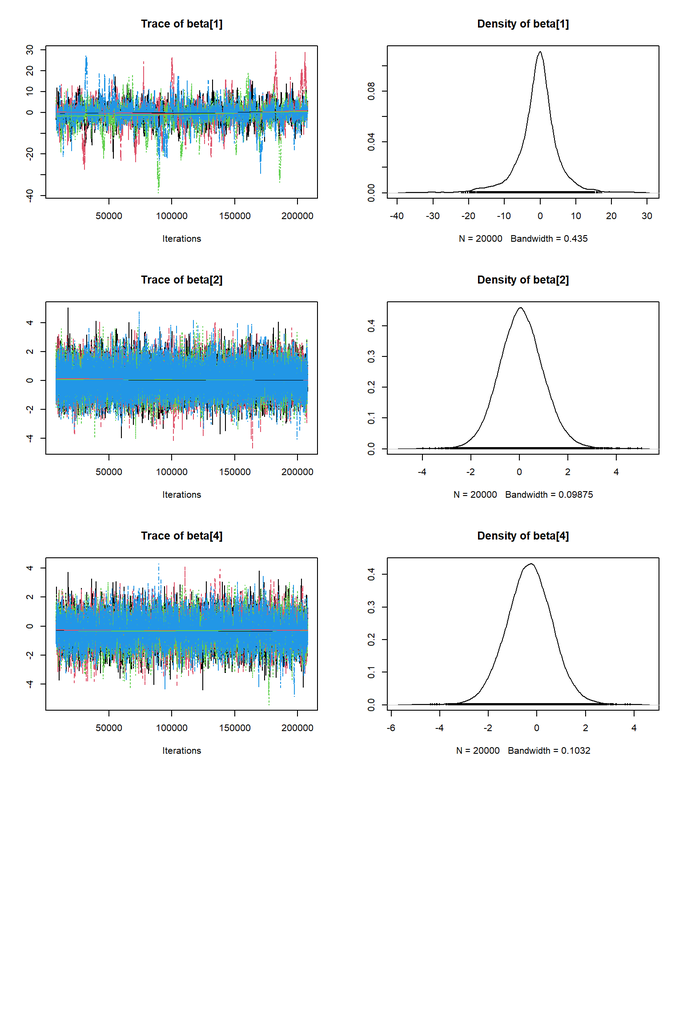

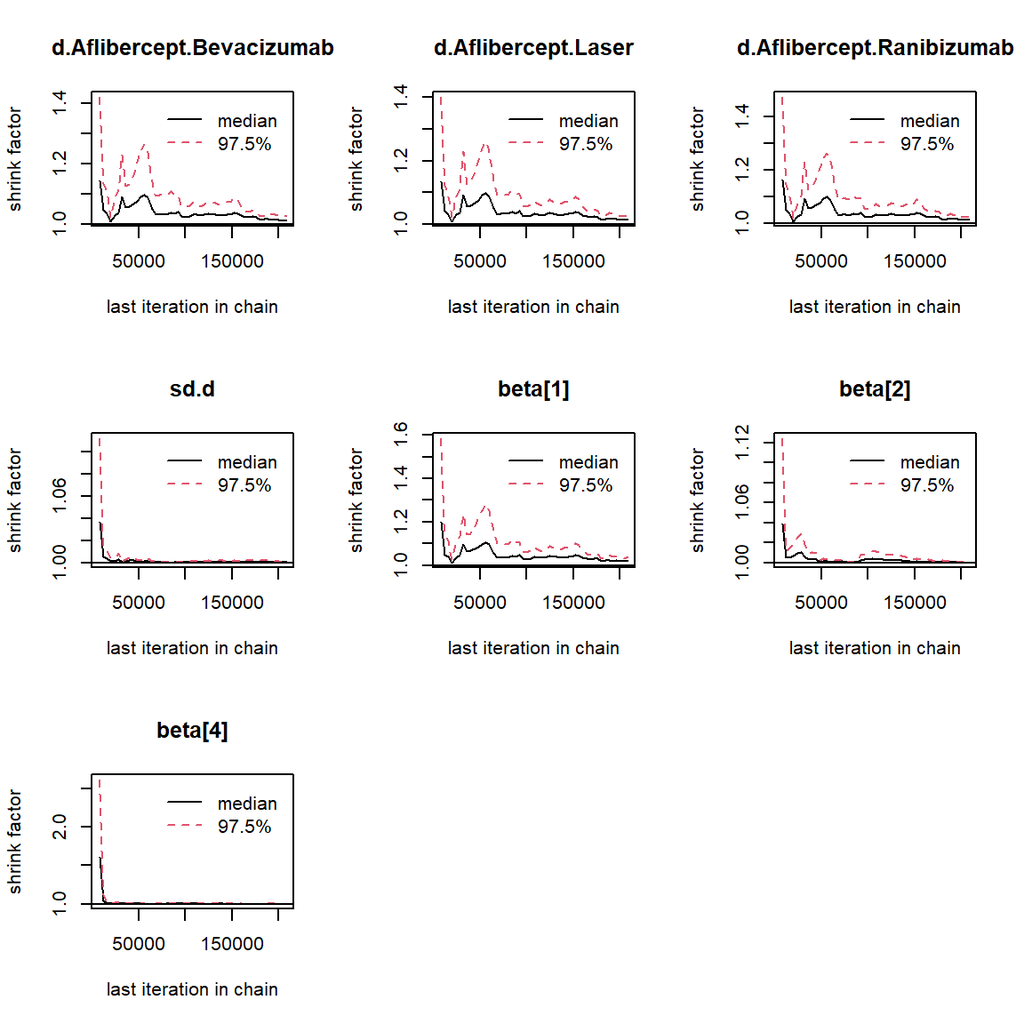

```
Potential scale reduction factors:

                          Point est. Upper C.I.
d.Aflibercept.Bevacizumab       1.02       1.03
d.Aflibercept.Laser             1.02       1.03
d.Aflibercept.Ranibizumab       1.02       1.03
sd.d                            1.00       1.00
beta[1]                         1.02       1.04
beta[2]                         1.00       1.00
beta[4]                         1.00       1.00
```

```
[1] "PSRF = 1.007"
```

Here are comparative forest plots comparing treatment effects against one another. I have fixed the birth weight to 1000g for illustrative purposes.

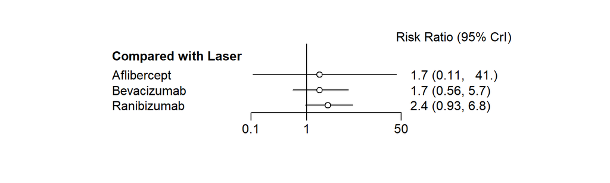

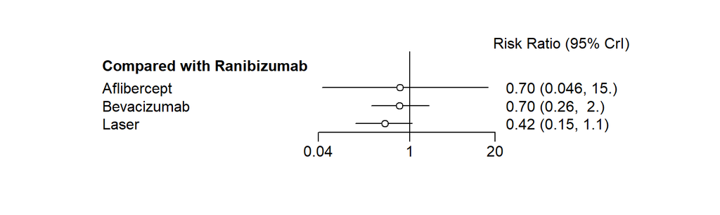

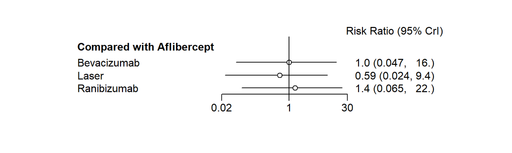

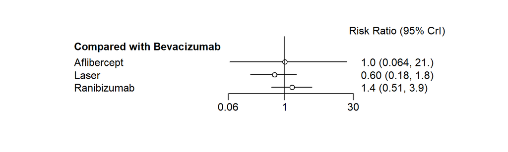

## Covariate plots for birth weight

Covariate plots below are in log(RR) units.

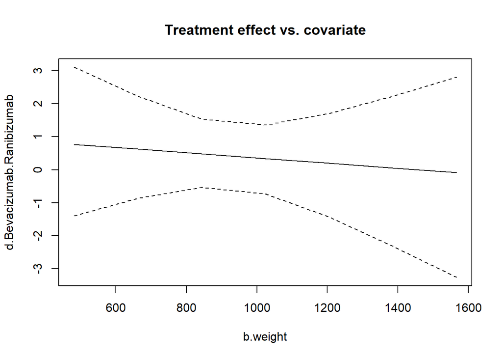

There are no significant differences between treatment outcomes in terms of retreatment rates between Avastin and Lucentis across various birth weights.

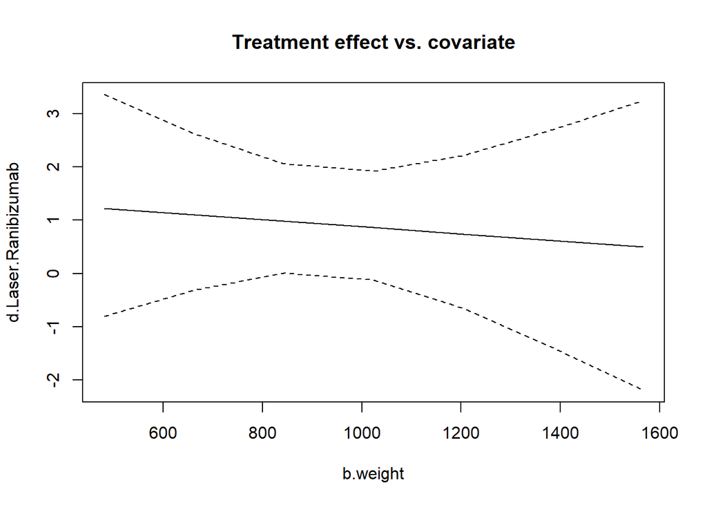

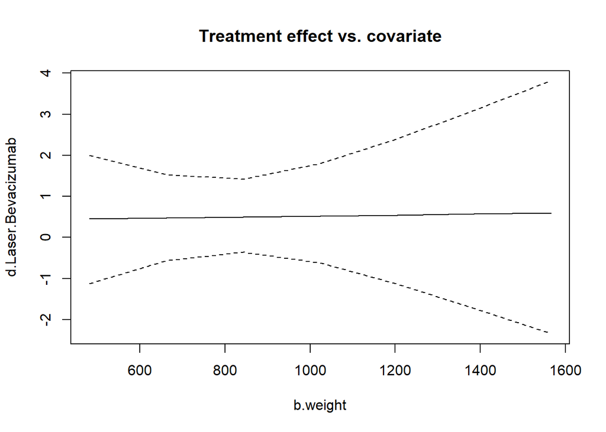

There are no significant differences between treatment outcomes in terms of retreatment rates between Avastin and Laser across various birth weights.

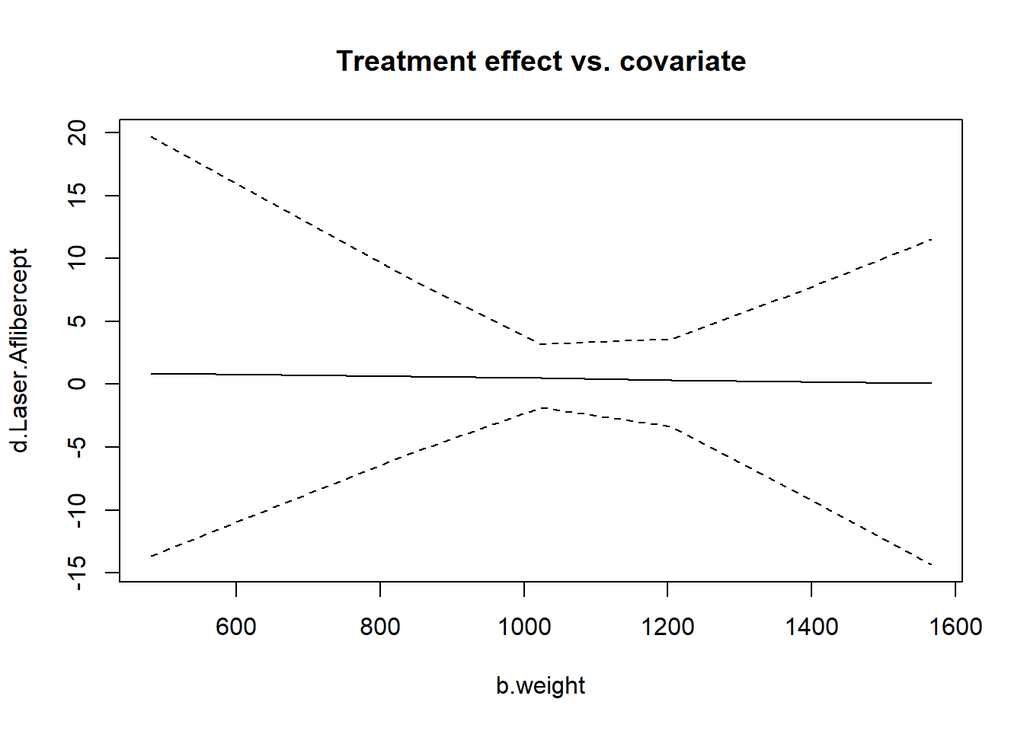

Again, there are no statistically significant differences in treatment outcomes in terms of retreatment rates evident between Eylea and any other treatment modality.

### Mean postmenstrual age at treatment - PMA at treatment (weeks) as a regressor in the Bayesian meta-regression (potential moderator)

```
Results on the Log Risk Ratio scale

Iterations = 8010:208000
Thinning interval = 10
Number of chains = 4
Sample size per chain = 20000

1. Empirical mean and standard deviation for each variable,
   plus standard error of the mean:

                              Mean     SD Naive SE Time-series SE
d.Aflibercept.Bevacizumab -0.06161 0.8343 0.002950       0.004996
d.Aflibercept.Laser       -0.27380 0.8585 0.003035       0.005205
d.Aflibercept.Ranibizumab  0.60837 0.7972 0.002818       0.004619
sd.d                       1.15007 0.3021 0.001068       0.001601
beta[1]                   -1.36006 2.7674 0.009784       0.015492
beta[2]                   -1.37750 0.9828 0.003475       0.008589
beta[4]                   -1.82917 0.9004 0.003183       0.007582

2. Quantiles for each variable:

                             2.5%     25%      50%     75%    97.5%
d.Aflibercept.Bevacizumab -1.7251 -0.5926 -0.05914  0.4696  1.59379
d.Aflibercept.Laser       -2.0205 -0.8179 -0.25824  0.2823  1.39813
d.Aflibercept.Ranibizumab -0.9804  0.1016  0.61044  1.1194  2.19158
sd.d                       0.6808  0.9363  1.10990  1.3176  1.85415
beta[1]                   -7.3401 -2.9909 -1.19701  0.4146  3.80137
beta[2]                   -3.3153 -2.0180 -1.38173 -0.7372  0.56591
beta[4]                   -3.6531 -2.4103 -1.81745 -1.2308 -0.09126

-- Model fit (residual deviance):

    Dbar       pD      DIC
53.73112 41.30826 95.03938

50 data points, ratio 1.075, I^2 = 9%

-- Regression settings:

Regression on "pma", unrelated coefficients, "Laser" as control
Input standardized: x' = (pma - 35.73435) / 3.718078
Estimates at the centering value: pma = 35.73435
```

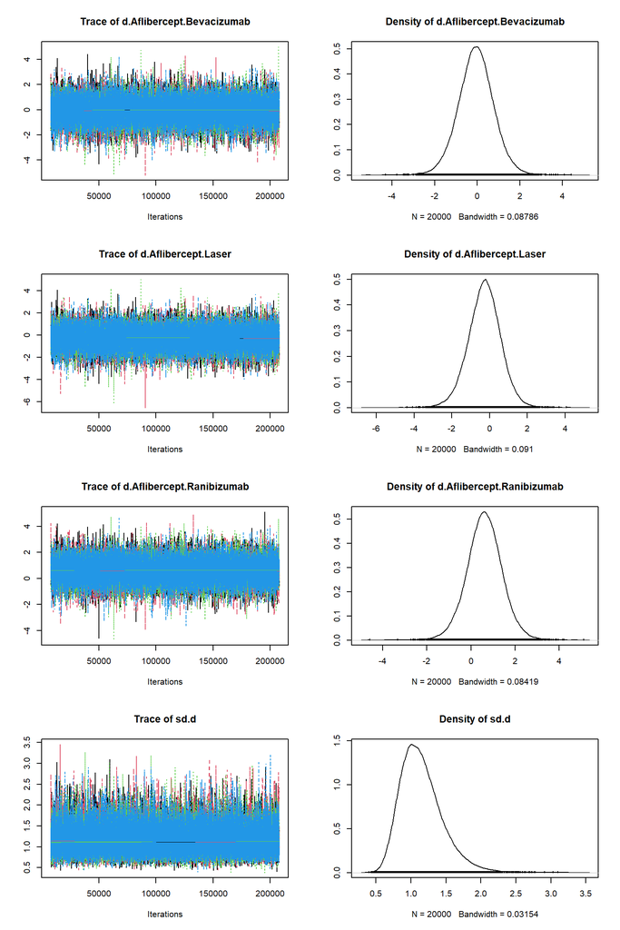

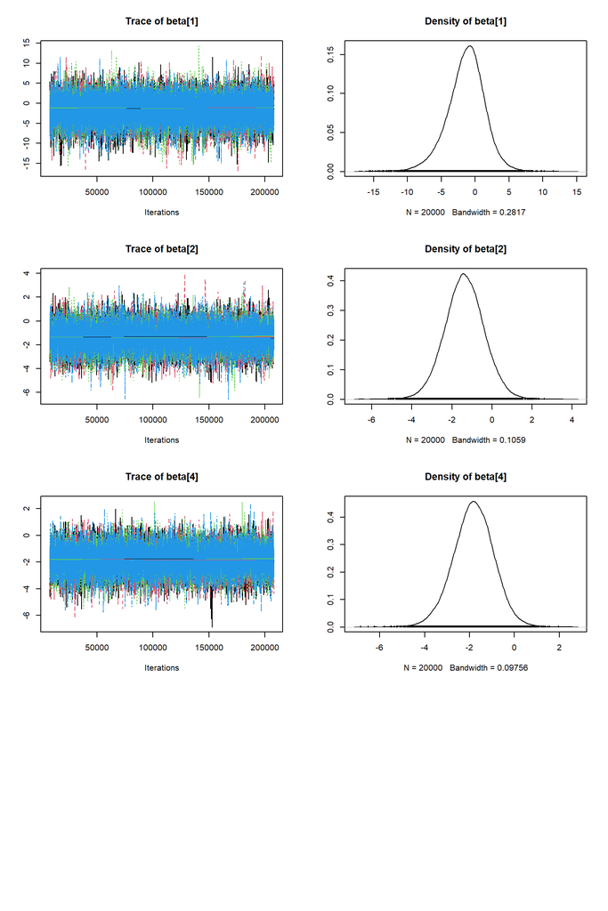

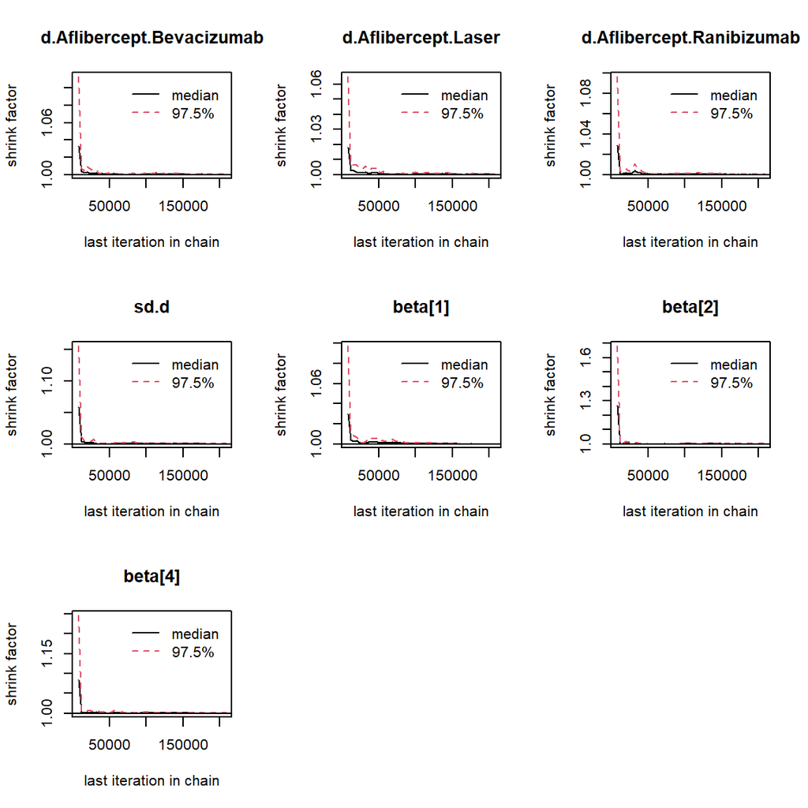

```
Potential scale reduction factors:

                          Point est. Upper C.I.
d.Aflibercept.Bevacizumab          1          1
d.Aflibercept.Laser                1          1
d.Aflibercept.Ranibizumab          1          1
sd.d                               1          1
beta[1]                            1          1
beta[2]                            1          1
beta[4]                            1          1
```

```
[1] "PSRF = 1.0005"
```

Here are comparative forest plots comparing treatment effects against one another. I have fixed the pma to 35 weeks for illustrative purposes.

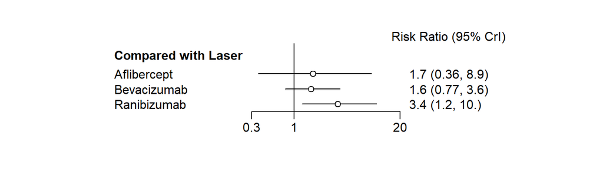

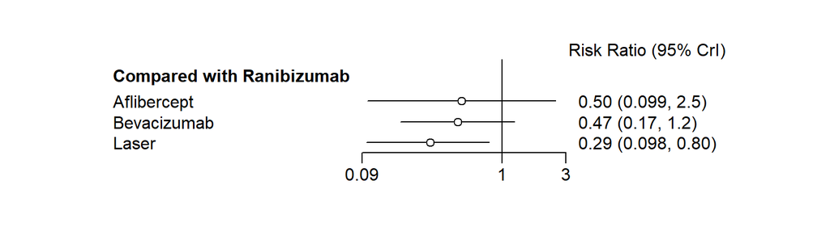

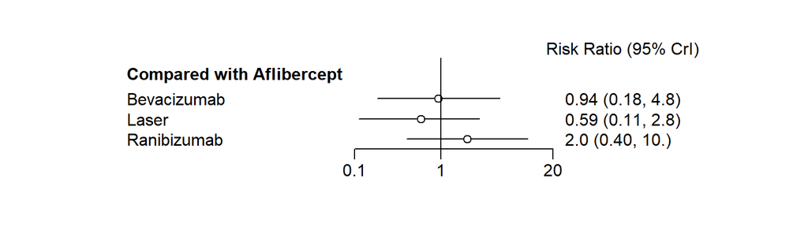

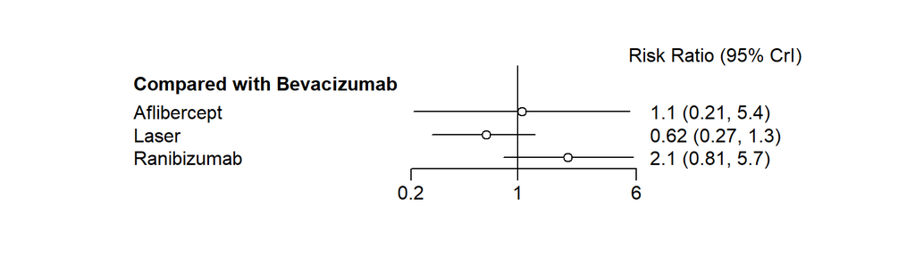

## Covariate plots for pma (weeks)

Covariate plots below are in log(RR) units.

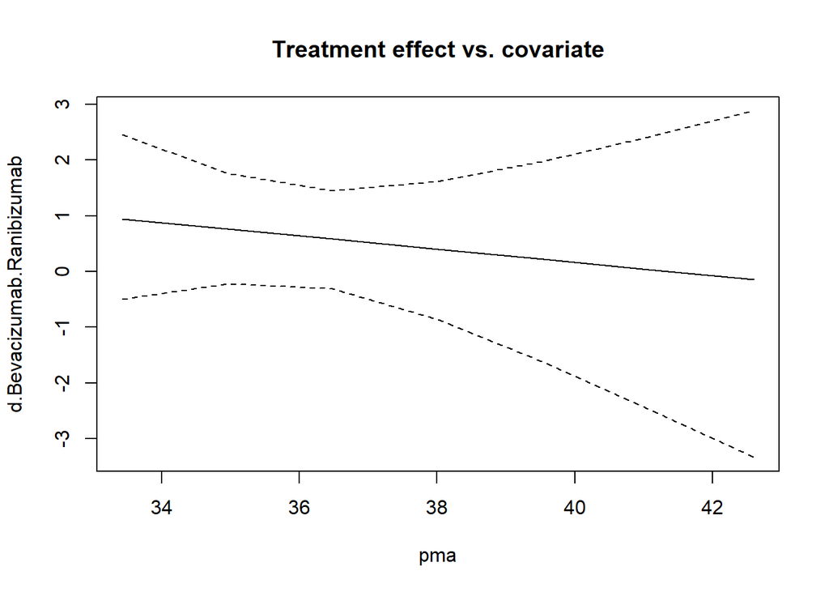

There are no significant differences between treatment outcomes in terms of retreatment rates between Avastin and Lucentis across various pma at treatment.

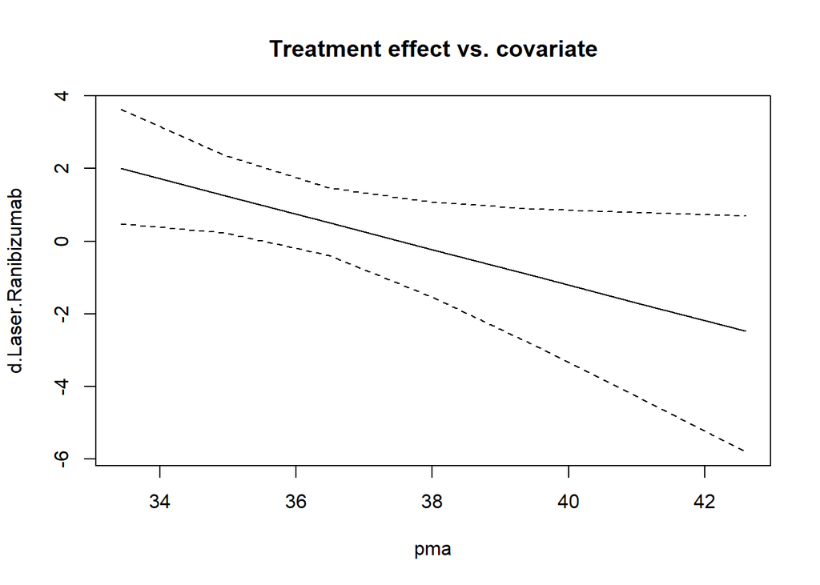

We have a statististical differences between Lucentis and Laser when taking mean PMA at treatment into account as a moderator. At low PMA (upto 35.6 weeks) treatment with Laser is associated with a statistically significant reduction in risk of requiring retreatment than Lucentis. Beyond 35.6 weeks PMA there are no statistical differences.

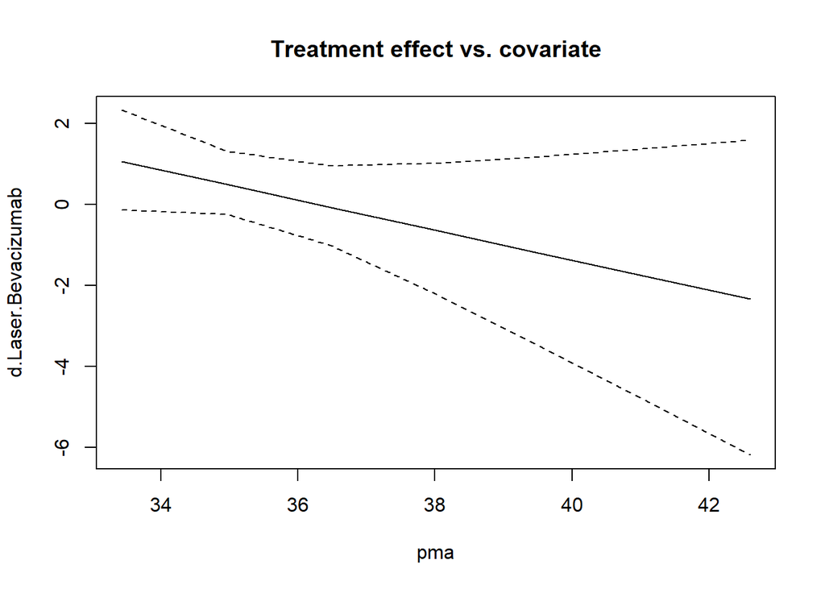

There are no significant differences between treatment outcomes in terms of retreatment rates between Avastin and Laser across various pma’s

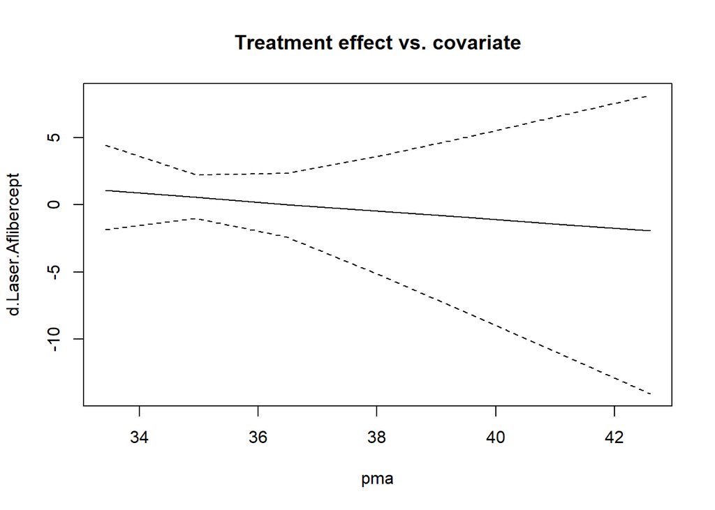

To summarize

At low PMA (upto 35.6 weeks) treatment with Laser is associated with a statistically significant reduction in risk of requiring retreatment than Lucentis.No other differences are seen at higher PMA or with any other treatment comparisons.